# Assessment

#### T2.10 Use the below function/ create a function of your own and drop null values from ('job'), ('marital'), ('education'), ('housing') (weightage 2 marks) AE

#### NOTE:

- Design a Function `drop` to drop Null values from the Data Frame
- Dropping null values from specific columns is a common data cleaning task to handle missing or incomplete data.
- By removing rows with missing values in specific columns, we ensure that the data used for analysis or modeling is complete and reliable.

```python
# Drops nulls
import numpy as np

def drop(column,df):
    # Code starts here

    df = df.dropna(subset=[column])

    return df

    # Code ends here
```

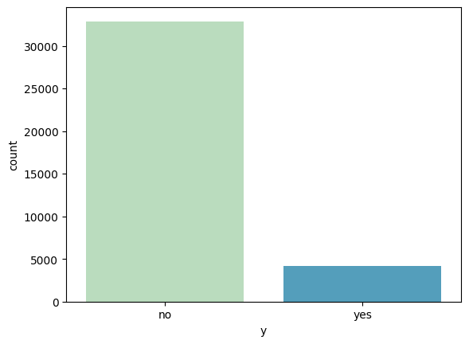

```
no     32876
yes     4208
Name: y, dtype: int64
```

```python
drop('job',df)
drop('marital',df)
drop('education',df)
drop('housing',df)

# df.info()

sns.countplot(data=df, x='y',palette='GnBu')
plt.show()

df['y'].value_counts()
```

#### T2.11 Perform data separation store all categorical variables in as ‘cat’ and All numeric variables in as ‘Numeric’ (weightage 2 marks) ME

#### NOTE:

- Data separation involves segregating different types of variables in a dataset based on their data types or characteristics.
- we aim to separate categorical variables, which represent qualitative attributes, from numeric variables, which represent quantitative attributes.
- Categorical variables are qualitative variables that represent categories or groups.
- Numeric variables are quantitative variables that represent numerical values.

```python
# Getting all catogorical variables

cat = df.select_dtypes(include=['object']).columns
Numeric = df.select_dtypes(include=['int64','float64']).columns
cat, Numeric
```

```
(Index(['y', 'job', 'marital', 'education', 'default', 'housing', 'loan',
        'contact', 'month', 'day_of_week', 'bcontacted', 'poutcome'],
       dtype='object'),
 Index(['age', 'duration', 'campaign', 'previous', 'emp.var.rate',
        'cons.price.idx', 'cons.conf.idx', 'euribor3m', 'nr.employed'],
       dtype='object'))
```

#### T2.12 Create countplot for all categorical variables (weightage 2 marks) ME

#### T2.12 Create countplot for all categorical variables (weightage 2 marks) ME

- Count plots are graphical representations that display the frequency or count of observations within different categories of a categorical variable.
- They provide a visual summary of the distribution of categorical data, making it easier to understand the relative frequencies of different categories.

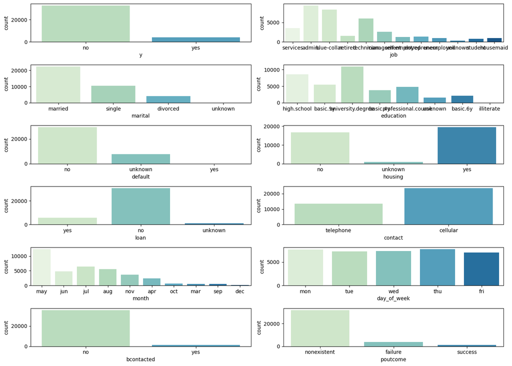

```python
import seaborn as sns
import matplotlib.pyplot as plt

# Code starts here
num_cols = 2
num_rows = (len(cat) + 1) // num_cols
fig, axes = plt.subplots(nrows=num_rows,ncols=num_cols, figsize=(14,10))
for i, column in enumerate(cat):
    row = i // num_cols
    col = i % num_cols
    sns.countplot(x=column, data=df, palette='GnBu', ax=axes[row,col])
plt.tight_layout()
plt.show()

# code ends here
```

#### T2.13 Change datatype for ‘month’ and ‘day_of_week’ as ‘str’ (weightage 2 marks) ME

- Numbers: to get number of numeric variables
- Changing the data type of columns to 'str' converts the numerical or categorical values in the columns to string format.
- This conversion is useful when treating these columns as categorical variables or when the values represent labels rather than numeric quantities.

```python
# Code starts here
df['month'] = df['month'].astype(str)
df['day_of_week'] = df['day_of_week'].astype(str)
# Code ends here
```

#### T2.14 Create histogram to know the Distribution of Attributes in the data frame df and check for normality (weightage 2 marks) ME

- Histograms are graphical representations of the distribution of numerical data.
- They provide a visual summary of the frequency or count of observations within different intervals, or "bins," of the data.

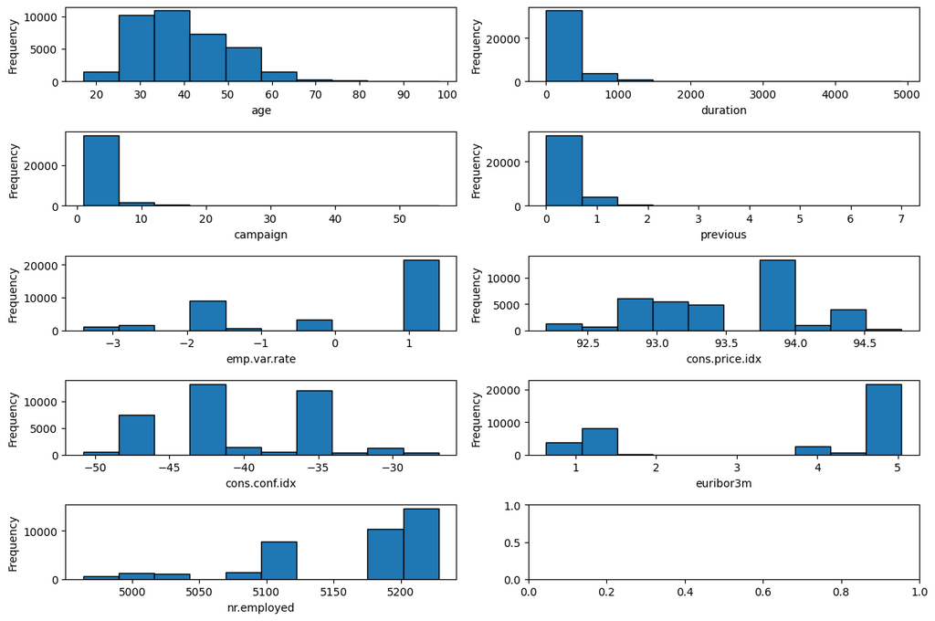

```python
# Code starts here
num_cols = 2
num_rows = (len(Numeric) + 1) // num_cols
fig, axes = plt.subplots(nrows=num_rows,ncols=num_cols, figsize=(12,8))
for i, column in enumerate(Numeric):
    row = i // num_cols
    col = i % num_cols
    axes[row,col].hist(df[column],bins=10,edgecolor='black')
    axes[row,col].set_xlabel(column)
    axes[row,col].set_ylabel('Frequency')
plt.tight_layout()
plt.show()

# Code ends here
```

#### T2.15 Get Descriptive Statistics for all numeric variables (weightage 2 marks) ME

- Hint: Using the code: np.log(df['campaign'] + 1) perform log transformation and create an histogram.
- To get descriptive statistics

```python
df.describe()
```

|  | age | duration | campaign | previous | emp.var.rate | cons.price.idx | cons.conf.idx | euribor3m | nr.employed |
| --- | --- | --- | --- | --- | --- | --- | --- | --- | --- |
| count | 37084.000000 | 37084.000000 | 37084.000000 | 37084.000000 | 37084.000000 | 37084.000000 | 37084.000000 | 37084.000000 | 37084.000000 |
| mean | 40.042714 | 258.237946 | 2.569545 | 0.172986 | 0.082669 | 93.576076 | -40.505183 | 3.621668 | 5167.058664 |
| std | 10.432965 | 258.730909 | 2.770611 | 0.495681 | 1.568997 | 0.578493 | 4.622045 | 1.733972 | 72.196605 |
| min | 17.000000 | 0.000000 | 1.000000 | 0.000000 | -3.400000 | 92.201000 | -50.800000 | 0.634000 | 4963.600000 |
| 25% | 32.000000 | 102.000000 | 1.000000 | 0.000000 | -1.800000 | 93.075000 | -42.700000 | 1.344000 | 5099.100000 |
| 50% | 38.000000 | 180.000000 | 2.000000 | 0.000000 | 1.100000 | 93.749000 | -41.800000 | 4.857000 | 5191.000000 |
| 75% | 47.000000 | 319.250000 | 3.000000 | 0.000000 | 1.400000 | 93.994000 | -36.400000 | 4.961000 | 5228.100000 |
| max | 98.000000 | 4918.000000 | 56.000000 | 7.000000 | 1.400000 | 94.767000 | -26.900000 | 5.045000 | 5228.100000 |

#### T2.16 Drop variable duration from df (weightage 1 marks) ME

- drop duration Coloumn
- Dropping a variable can impact subsequent analysis, such as descriptive statistics, exploratory data analysis, or predictive modeling.
- Ensure that dropping the "duration" variable does not compromise the integrity or quality of the dataset.

```python
df = df.drop(columns=['duration'])
```

```python
df.info()
```

```
<class 'pandas.core.frame.DataFrame'>
RangeIndex: 37084 entries, 0 to 37083
Data columns (total 20 columns):
 #   Column          Non-Null Count  Dtype
---  ------          --------------  -----
 0   y               37084 non-null  object
 1   age             37084 non-null  int64
 2   job             37084 non-null  object
 3   marital         37084 non-null  object
 4   education       37084 non-null  object
 5   default         37084 non-null  object
 6   housing         37084 non-null  object
 7   loan            37084 non-null  object
 8   contact         37084 non-null  object
 9   month           37084 non-null  object
 10  day_of_week     37084 non-null  object
 11  campaign        37084 non-null  int64
 12  bcontacted      37084 non-null  object
 13  previous        37084 non-null  int64
 14  poutcome        37084 non-null  object
 15  emp.var.rate    37084 non-null  float64
 16  cons.price.idx  37084 non-null  float64
 17  cons.conf.idx   37084 non-null  float64
 18  euribor3m       37084 non-null  float64
 19  nr.employed     37084 non-null  float64
dtypes: float64(5), int64(3), object(12)
memory usage: 5.7+ MB
```

`Correlation Heatmap`:

- Use seaborn's heatmap function to create a correlation heatmap.
- The heatmap displays correlation coefficients between pairs of variables.

`Scatter Plot`:

- Use seaborn's scatterplot function to create scatter plots between pairs of variables.
- Scatter plots visualize the relationship between two continuous variables.

`Pearson's Correlation Coefficient`:

- Calculate Pearson's correlation coefficient (also known as Pearson's r) to quantify the strength and direction of the linear relationship between two continuous variables.
- Pearson's r ranges from -1 to 1, where:
  - 1 indicates a perfect positive linear relationship,
  - -1 indicates a perfect negative linear relationship, and 0 indicates no linear relationship.

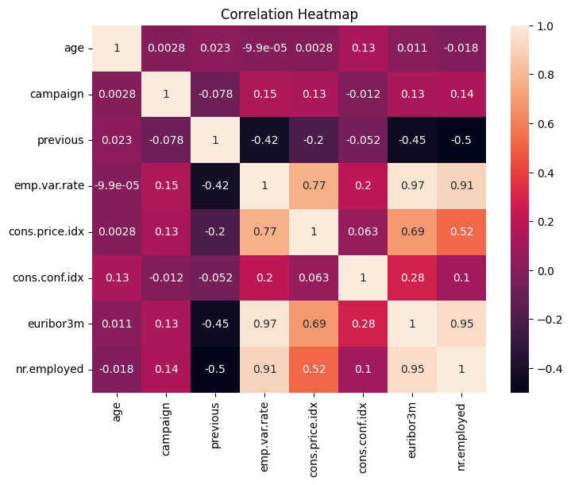

```python
corr_mattrix = df.corr()
plt.figure(figsize=(8,6))
sns.heatmap(corr_mattrix,annot=True)
plt.title("Correlation Heatmap")
plt.show()
```

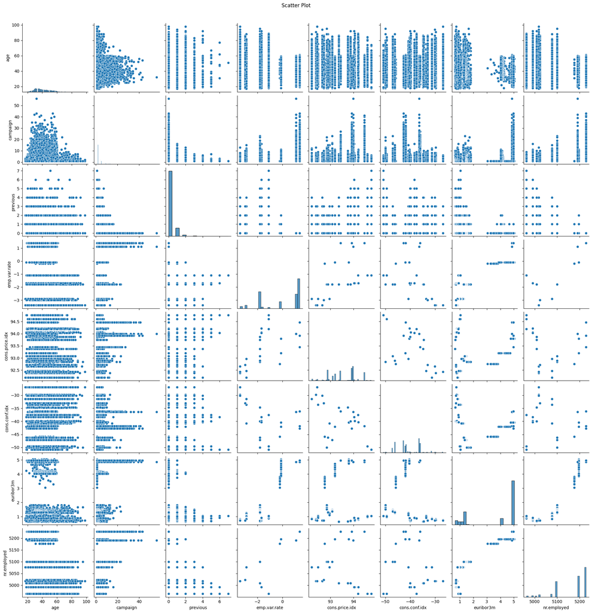

```python
sns.pairplot(df)
plt.suptitle("Scatter Plot",y=1.02)
plt.show()
```

```python
pearson_corr = df['age'].corr(df['previous'])
pearson_corr
```

```
0.022896928964986938
```

#### NOTE:

- This function `dummy_function` should convert categorical variables into dummy variables using one-hot encoding, a common preprocessing technique in machine learning.
- It must take a DataFrame (data) containing categorical variables as input.

```python
# df_features = df.iloc[:,:-1]
#print(df_features)

def dummy_function(data):
    # df_features = df.iloc[:,:-1]
    df_features1 = None

    # Code starts here
    cat = data.select_dtypes(include=['object']).columns
    df_features1 = pd.get_dummies(data, columns = cat, drop_first=True)
    # Code ends here
    return df_features1

#display(df_features.head(5))
```

```python
df_features=dummy_function(df)
```

```python
df_features.info()
```

```
<class 'pandas.core.frame.DataFrame'>
RangeIndex: 37084 entries, 0 to 37083
Data columns (total 53 columns):
 #   Column                         Non-Null Count  Dtype
---  ------                         --------------  -----
 0   age                            37084 non-null  int64
 1   campaign                       37084 non-null  int64
 2   previous                       37084 non-null  int64
 3   emp.var.rate                   37084 non-null  float64
 4   cons.price.idx                 37084 non-null  float64
 5   cons.conf.idx                  37084 non-null  float64
 6   euribor3m                      37084 non-null  float64
 7   nr.employed                    37084 non-null  float64
 8   y_yes                          37084 non-null  uint8
 9   job_blue-collar                37084 non-null  uint8
```

[output cut: 45 more lines]

### Task 3: Build model for predicting after splitting the dataset (weightage - 15 marks)

#### NOTE:

- Split the dataset into X and y, with test_size=0.33 and random_state=42

```python
X = df_features.copy()
X.drop(columns=['y_yes'])
y = df['y']
X_train, X_test, y_train, y_test = train_test_split(X, y, test_size = 0.33, random_state = 42)
```

```python
X.shape, y.shape
```

```
((37084, 53), (37084,))
```

#### T3.1 RandomForestClassifier(n_estimators=100, random_state=42), n_features_to_select=20) (weightage 5 marks) ME

- Save the code for model versioning

#### NOTE:

- Build a machine learning model for classification using random forest.
- Employ recursive feature elimination (RFE) for feature selection.
- The function should take input features X and target variable y.
- The function can iterate over a range of n_features, which specifies the number of features to select.

```python
from sklearn.feature_selection import RFE
from sklearn.model_selection import train_test_split
from sklearn.ensemble import RandomForestClassifier
from sklearn.metrics import accuracy_score

def select_features(X, y, test_size=0.2, n_features=[20]):
    features = None
    np.warnings.filterwarnings('ignore')

    # Code starts here
    X_train, X_test, y_train, y_test = train_test_split(X, y, test_size = test_size, random_state = 42)
    rfclf = RandomForestClassifier(n_estimators=100, random_state = 42)
    selector = RFE(estimator=rfclf, n_features_to_select = n_features[0], step=1)
    selector.fit(X_train, y_train)
    features = X.columns[selector.support_]
   # Code ends here

    return features, selector
```

```python
select, selector = select_features(X, y)
```

```python
select
```

```
Index(['age', 'campaign', 'previous', 'emp.var.rate', 'cons.price.idx',
       'cons.conf.idx', 'euribor3m', 'nr.employed', 'y_yes', 'job_technician',
       'marital_married', 'education_university.degree', 'housing_yes',
       'contact_telephone', 'month_mar', 'month_oct', 'day_of_week_mon',
       'bcontacted_yes', 'poutcome_nonexistent', 'poutcome_success'],
      dtype='object')
```

### Classification model

#### T3.2 Create KNN model using the following parameters, KNeighborsClassifier(n_neighbors=10) Save the code for model versioning (weightage 5 marks) ME

#### NOTE:

- Build a machine learning model for classification using KNeighbors.
- The function should take input features (df_features), target feature (target_feature), and a list of features to consider (features).
- The function can iterate over a range of n_features, which specifies the number of features to select.
- The function must create a KNN classifier with the specified number of neighbors and fits it to the training data.

```python
from sklearn.neighbors import KNeighborsClassifier
from sklearn.model_selection import train_test_split

def build_knn_model(df_features, target_feature, features):
    knn = None

    # Code starts here
    X_selected = df_features[features]
    X_train, X_test, y_train, y_test = train_test_split(X_selected, y, test_size = 0.2, random_state = 42)
    knn = KNeighborsClassifier(n_neighbors=10)
    knn.fit(X_train, y_train)
    # Code ends here

    return knn  # Returning the trained model
```

```python
# Call the function to build the KNN model
knn_model = build_knn_model(df_features, df['y'], select)
```

```python
knn_model
```

```
KNeighborsClassifier(n_neighbors=10)
```

#### T3.3 Create a Gradient boosting classifier model using the following parameters , GradientBoostingClassifier with options: n_estimators=100, random_state=42, max_depth=1. Save the code for model versioning (weightage 5 marks) ME

- Gradient Boosting

#### NOTE:

- Build a machine learning model for classification using Gradient Boosting.
- define a function `build_gbrt_model` that takes input features X, target variable y, and some optional parameters like random_state, n_estimators, max_depth, and test_size.

```python
from sklearn.ensemble import GradientBoostingClassifier
from sklearn.model_selection import train_test_split

def build_gbrt_model(X, y, random_state=42, n_estimators=100, max_depth=1, test_size=0.2):
    gbrt = None

    # Code starts here
    X_train, X_test, y_train, y_test = train_test_split(X, y, test_size = test_size, random_state = 42)
    gbrt = GradientBoostingClassifier(n_estimators=n_estimators, max_depth=max_depth, random_state=random_state)
    gbrt.fit(X_train, y_train)
    # Code ends here
    return gbrt
```

```python
gbrt=build_gbrt_model(X, y)
```

```python
gbrt
```

```
GradientBoostingClassifier(max_depth=1, random_state=42)
```